# Healthcare Needs Report

Sudeep Santhosh

```r
library(lme4)
library(tidyverse)
library(here)
library(haven)
library(labelled)
library(sjlabelled)
library(ggplot2)
library(dplyr)
library(sjPlot)
library(naniar)
library(tinytable)
library(ggmosaic)
options(tinytable_tt_digits = 3)
options(tinytable_latex_placement = "H")
```

# Data loading

The `.sav` format was selected for data loading because it preserves variable labels, data types, and metadata more effectively than flat file formats such as `.csv`. This is particularly useful for analytically work.

```r
healthy_wave=haven::read_sav(here("data","CRONOS3 Theme - Make it Healthy.sav"))
dictionary=labelled::generate_dictionary(healthy_wave)
saveRDS(healthy_wave, here("data", "healthy_wave.rds"))
```

# Exploratory Data Analysis (EDA)

## Duplicate value

```r
sum(duplicated(healthy_wave$idno))
```

```
## [1] 1431
```

```r
healthy_wave$needed_any=ifelse(
  rowSums(healthy_wave[, c("w1hq1", "w1hq3", "w1hq6", "w1hq11")] == 1, na.rm = TRUE) > 0,
  1, 0
)
```

```r
healthy_wave %>%
  filter(idno==25213)|>
  select(cntry,age,idno)|>
  haven::as_factor() |>
  tt()
```

| cntry | age | idno |
| --- | --- | --- |
| Czechia | 74 | 25213 |
| Finland | 70 | 25213 |

Checking id-25213

In `healthy_wave1`, 25213 id has two entries with countries as CZ and FI.

Trying to see how the ids are filled, realized that for every country there is a given range of values assigned.

So as to create unique values, we will be merging `cntry` and `idno` to create a new value, which will be the new primary key for filtering.

Solution-1 solving duplicates by merging the `cntry` and `idno` column

```r
primary_health_wave=healthy_wave|>
  mutate(new_id=paste(cntry,idno,sep= "_"))
sum(duplicated(primary_health_wave$new_id))
```

```
## [1] 21
```

still 21 duplicate values exist so we merge another column which is `age` to create a primary key in the dataset also to check if its not just the same person and not at different ages / years we had to check this

```r
primary_health_wave|>
  filter(duplicated(new_id) | duplicated(new_id,fromLast=TRUE)) |>
  arrange(new_id)|>
  select(cntry, new_id,age,gndr)|>
  haven::as_factor()|>
  slice_head(n=12)|>
  tt()
```

| cntry | new_id | age | gndr |
| --- | --- | --- | --- |
| Austria | AT_56678 | 61 | Male |
| Austria | AT_56678 | 75 | Female |
| United Kingdom | GB_50416 | 58 | Male |
| United Kingdom | GB_50416 | 48 | Male |
| United Kingdom | GB_57250 | 46 | Female |
| United Kingdom | GB_57250 | 83 | Male |
| United Kingdom | GB_58627 | 40 | Male |
| United Kingdom | GB_58627 | 42 | Male |
| United Kingdom | GB_60237 | 49 | Male |
| United Kingdom | GB_60237 | 46 | Male |
| United Kingdom | GB_64252 | 72 | Female |
| United Kingdom | GB_64252 | 61 | Female |

from this we can say that none of them are the same person as there huge again difference gap of more than one year

on merging with with three columns which is `age` ,`idno` and `cntry` we were able to remove the duplicates so now we can use this column as a primary key for identifying an individual

```r
primary_health_wave=primary_health_wave|>
  mutate(new_id=paste(cntry,idno,age, sep="_"))
sum(duplicated(primary_health_wave$new_id))
```

```
## [1] 0
```

## Model parametrs at intial phase

no of people who Needed to see a general practitioner last 12 months but could not

```r
sum(healthy_wave$w1hq1 ==1,na.rm = TRUE)
```

```
## [1] 426
```

no fo people who Needed to see dentist last 12 months but could not

```r
sum(healthy_wave$w1hq6 ==1,na.rm = TRUE)
```

```
## [1] 472
```

no of people Needed to see medical specialists but could not

```r
sum(healthy_wave$w1hq3 == 1, na.rm = TRUE)
```

```
## [1] 324
```

```r
length(healthy_wave$idno[
  which(healthy_wave$w1hq6==1|
        healthy_wave$w1hq3==1|
        healthy_wave$w1hq1==1|
        healthy_wave$w1hq11==1)
])
```

```
## [1] 1048
```

we have increased the number of observation to 1048

### Variable Description Table

| Variable | Role | Description |
| --- | --- | --- |
| w1hq1 | Response | Needed to see a general practitioner in the last 12 months |
| w1hq3 | Response | Needed to see medical specialists in the last 12 months |
| w1hq6 | Response | Needed to see dentist in the last 12 months |
| w1hq11 | Response | Needed diagnostic tests or scans prescribed by a doctor in the last 12 months |
| w1hq5 | Predictor | Wait time for medical specialist appointment |
| cntry | Predictor | Country |
| age | Predictor | Age |
| gndr | Predictor | Gender |
| w3hq77 | Predictor | Currently in paid work |
| w3hq57 | Predictor | Subjective mental health in general |
| w3hq58 | Predictor | Subjective physical health in general |
| w3hq87 | Predictor | Difficulty taking an hour off for personal/family matters during work |
| w5hq18 | Predictor | Healthcare costs covered by system |
| w5hq11 | Predictor | Receive help and support from close contacts when needed |
| w5hq8 | Predictor | Severe financial difficulties in family during first 18 years of life |
| w5hq17 | Predictor | Out-of-pocket cost for most recent private mental health consultation |
| w5hq12 | Predictor | Felt lonely during the past week |

## Country wise analysis

```r
country_summary=primary_health_wave|>
  group_by(cntry)|>
  summarise(
    total_people=n(),
    people_needed=sum(needed_any, na.rm = TRUE),
    proportion=people_needed/total_people
  )|>
  haven::as_factor() |>
  tt()
country_summary
```

| cntry | total_people | people_needed | proportion |
| --- | --- | --- | --- |
| Austria | 1040 | 50 | 0.0481 |
| Belgium | 1294 | 39 | 0.0301 |
| Czechia | 944 | 79 | 0.0837 |
| Finland | 1817 | 165 | 0.0908 |
| France | 1209 | 92 | 0.0761 |
| United Kingdom | 1370 | 184 | 0.1343 |
| Hungary | 757 | 64 | 0.0845 |
| Iceland | 1141 | 83 | 0.0727 |
| Poland | 645 | 83 | 0.1287 |
| Portugal | 779 | 101 | 0.1297 |
| Slovenia | 1151 | 108 | 0.0938 |

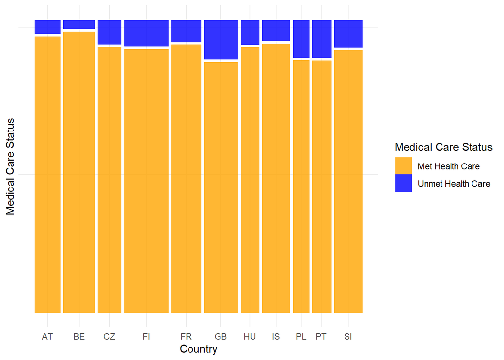

```r
ggplot(primary_health_wave)+
  geom_mosaic(aes(x=product(needed_any,cntry),
                  fill=needed_any))+
  scale_x_productlist("Country") +
  scale_y_productlist("Medical Care Status") +
  scale_fill_manual(
    values = c("orange", "blue"),
    name = "Medical Care Status"
  ) +
  theme_minimal()+
  theme(
    axis.text.y = element_blank(),
    axis.ticks.y = element_blank()
  )
```

The mosaic plot suggests that, across all countries, most respondents reported having their medical care needs met. However, the proportion of unmet health care need varies by country, with relatively higher shares observed in countries such as **GB(United Kingdom)**, **PL(Poland)**, **PT(Portugal)**, and **FI(Finland)**. This indicates potential cross-country differences in access to or delivery of medical care services.

```r
country_summary1=primary_health_wave|>
  group_by(cntry)|>
  summarise(
    people_needed=sum(needed_any == "Unmet Health Care", na.rm = TRUE),
  )|>
  arrange(desc(people_needed))|>
  haven::as_factor() |>
  tt()


country_summary1
```

| cntry | people_needed |
| --- | --- |
| United Kingdom | 184 |
| Finland | 165 |
| Slovenia | 108 |
| Portugal | 101 |
| France | 92 |
| Iceland | 83 |
| Poland | 83 |
| Czechia | 79 |
| Hungary | 64 |
| Austria | 50 |
| Belgium | 39 |

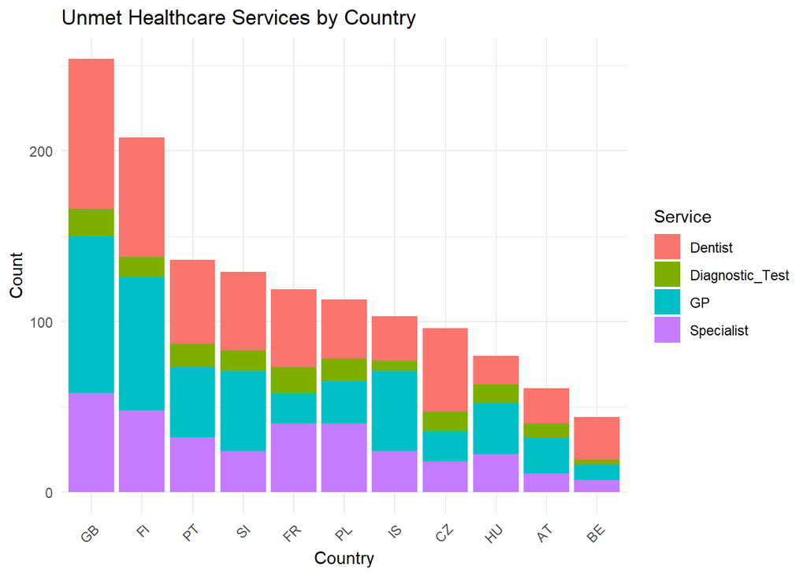

```r
service_country=primary_health_wave|>
  group_by(cntry)|>
  summarise(
    GP=sum(w1hq1==1,na.rm=TRUE),
    Specialist=sum(w1hq3==1,na.rm=TRUE),
    Dentist=sum(w1hq6==1,na.rm=TRUE),
    Diagnostic_Test=sum(w1hq11==1,na.rm=TRUE))|>
  pivot_longer(
    cols=-cntry,
    names_to="Service",
    values_to="Count")
ggplot(service_country,aes(x=reorder(cntry,-Count),y=Count,fill=Service))+
  geom_bar(stat="identity")+
  labs(title="Unmet Healthcare Services by Country",
    x="Country",
    y="Count")+
  theme_minimal()+
  theme(axis.text.x=element_text(angle=45,hjust=1))
```

## Variable Analysis thorugh likert charts

| Variable | Description |
| --- | --- |
| w3hq57 | Subjective mental health in general |
| w3hq58 | Subjective physical health in general |
| w5hq12 | Felt lonely, how much of the time in the past week |

```r
label_summary <- tibble(
  Variable = c(
    "Subjective mental health in general",
    "Subjective physical health in general",
    "Felt lonely, how much of the time past week"
  ),
  Labels = c(
    paste(names(attr(healthy_wave$w3hq57, "labels")), collapse = ", "),
    paste(names(attr(healthy_wave$w3hq58, "labels")), collapse = ", "),
    paste(names(attr(healthy_wave$w5hq12, "labels")), collapse = ", ")
  )
)

tt(label_summary)
```

| Variable | Labels |
| --- | --- |
| Subjective mental health in general | Very good, Good, Fair, Bad, Very bad, No answer |
| Subjective physical health in general | Very good, Good, Fair, Bad, Very bad, No answer |
| Felt lonely, how much of the time past week | None or almost none of the time, Some of the time, Most of the time, All or almost all of the time, No answer |

The labels Very Positive, Positive, Decent, Negative, and Very Negative were chosen to create a consistent ordinal framework across the three well being variables: `loneliness`, `subjective mental health`, and `subjective physical health`. Although the original survey items use slightly different response wording (for example, frequency-based responses for loneliness and quality-based responses for health status), recoding them into a common directional scale improves the comparability and interpret ability of the Likert chart.

```r
primary_health_wave$lonely=factor(primary_health_wave$w5hq12,levels = c(1, 2, 3, 4),labels = c("Very Positive","Positive","Decent","Negative" ),ordered = TRUE)

primary_health_wave$mental_state=factor(primary_health_wave$w3hq57,levels = c(1, 2, 3, 4,5),labels = c("Very Positive","Positive","Decent","Negative","Very Negative"),ordered = TRUE)
primary_health_wave$physical_state=factor(primary_health_wave$w3hq58,levels = c(1, 2, 3, 4,5),labels = c("Very Positive","Positive","Decent","Negative","Very Negative"),ordered = TRUE)

df_yes=primary_health_wave[primary_health_wave$needed_any== "Unmet Health Care", ]
df_no=primary_health_wave[primary_health_wave$needed_any=="Met Health Care", ]
```

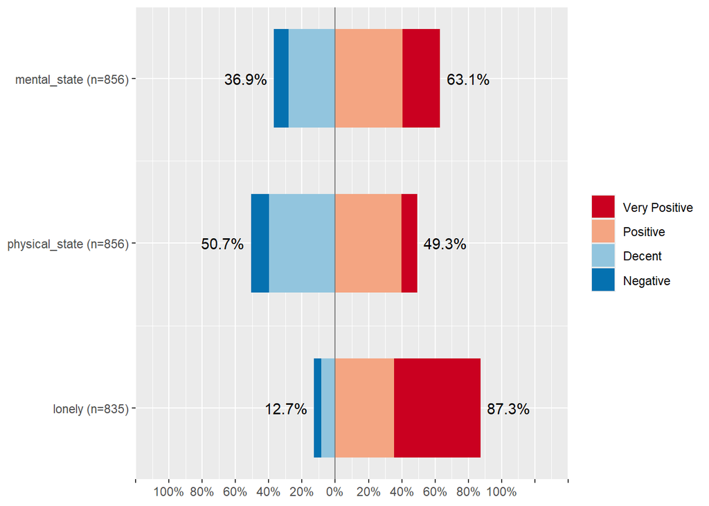

```r
plot_likert(df_yes[,c("mental_state", "physical_state","lonely")],
grid.range = c(1.2, 1.4),
expand.grid = FALSE,
values = "sum.outside",
show.prc.sign = TRUE,geom.colors = "RdBu")
```

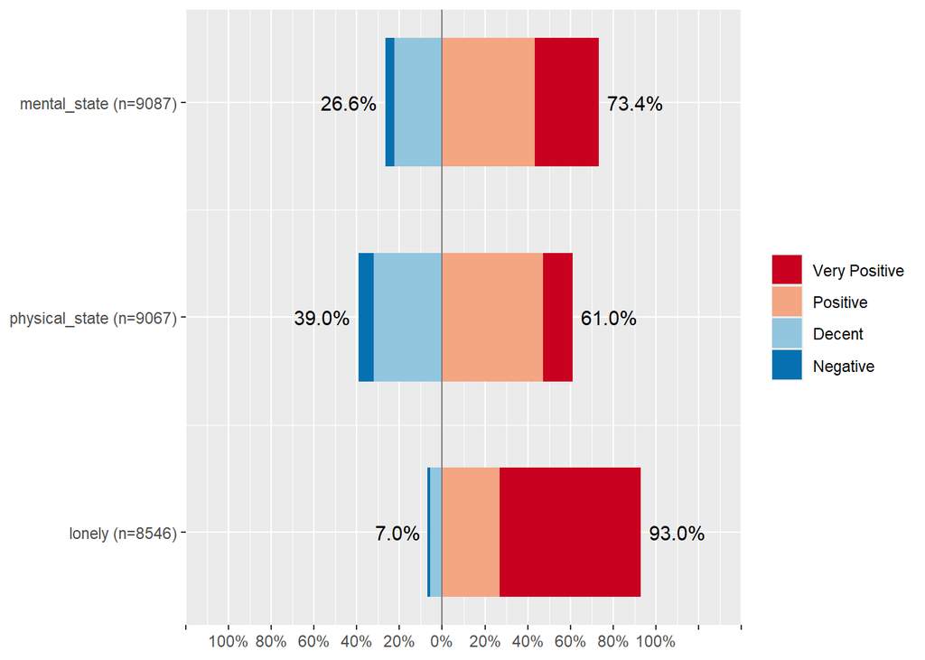

```r
plot_likert(df_no[,c("mental_state", "physical_state","lonely")],
grid.range = c(1.2, 1.4),
expand.grid = FALSE,
values = "sum.outside",
show.prc.sign = TRUE,geom.colors = "RdBu")
```

## Missing Data Analysis

| Variable Code | Description |
| --- | --- |
| w3hq87 | How difficult to take an hour off for personal/family matters during work |
| w5hq18 | Healthcare costs covered by system |
| w5hq11 | Receive help and support from close contacts when needed |
| w5hq8 | Severe financial difficulties in family during first 18 years of life, how often |
| w5hq17 | Out-of-pocket cost for most recent private mental health consultation |
| w5hq12 | Felt lonely, how much of the time past week |
| w3hq77 | Currently in paid work |

```r
missing_raw=miss_var_summary(
  df_yes[, c("w3hq87", "w5hq18", "w5hq11", "w5hq8", "w5hq17", "w5hq12","w3hq77")]
)
missing_table=tibble(
  Variable=c(
    "Time off work difficulty",
    "Healthcare cost coverage",
    "Social support",
    "Childhood financial difficulty",
    "Mental health consultation cost",
    "Loneliness",
    "Currently in paid work"
  ),
  Missing_Count=as.numeric(missing_raw$n_miss),
  Missing_Percentage=as.numeric(missing_raw$pct_miss)
)
tt(missing_table)
```

[output not shown]

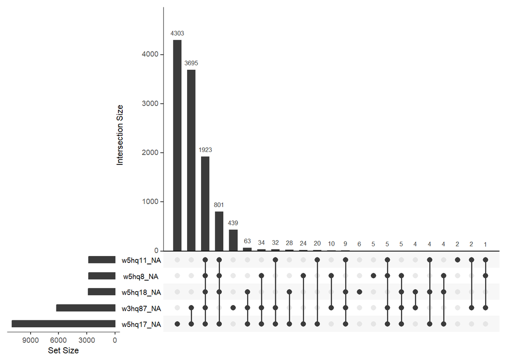

```r
gg_miss_upset(primary_health_wave[,c("w3hq87", "w5hq18","w5hq11","w5hq8","w5hq17","w5hq12","w3hq77")])
```

removing both those column remove a high chunk of missing values as we can see `w5hq17` and a combination of both `w3hq87` with `w5hq17` have the most missing values

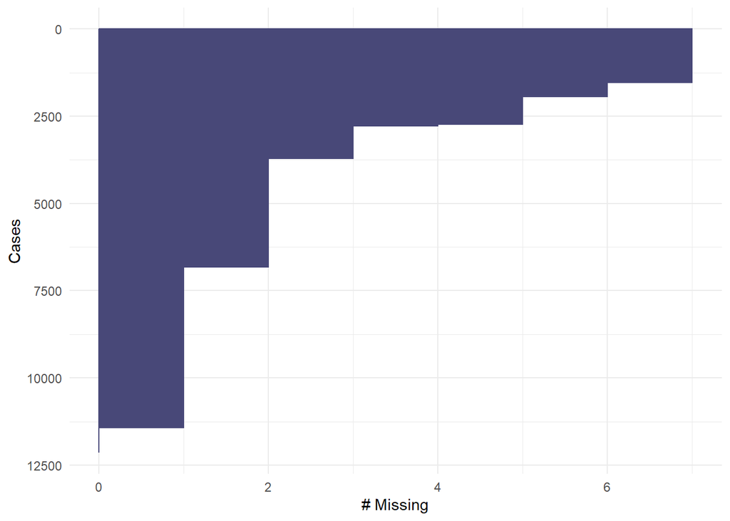

```r
gg_miss_case(primary_health_wave[,c("w3hq87", "w5hq18","w5hq11","w5hq8","w5hq17","w5hq12","w3hq77")])
```

comparing the miss cases on removing the two columns

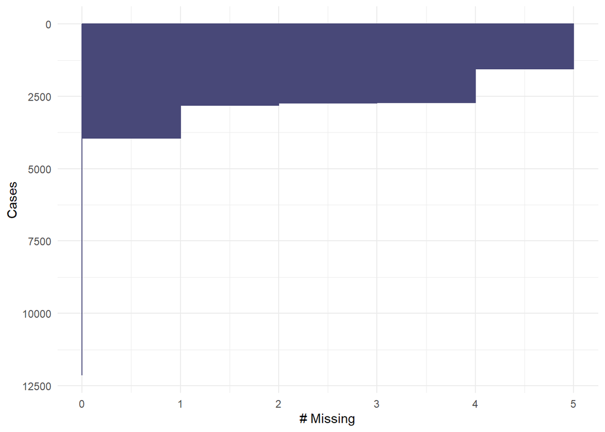

```r
gg_miss_case(primary_health_wave[,c( "w5hq18","w5hq11","w5hq8","w5hq12","w3hq77")])
```